# DataBaseball

# On deck: Import the packages we’ll need

“There’s a package for that!”

```r
library(Lahman) # Our source data
library(tidyverse)  # "Metapackage," don't leave home without it!
library(psych)  # Descriptive stats
library(skimr)  # Data profiling
library(writexl) # Write to Excel -- data dump
library(openxlsx) # Write to Excel -- plus
```

# 1st base: Import the data

We can pull this data from the `Teams` and `Salary` tables of `Lahman`

```r
head(Teams)
```

|  | yearID | lgID | teamID | franchID | divID | Rank | G | Ghome | W | L | DivWin | WCWin | LgWin | WSWin | R | AB | H | X2B | X3B | HR | BB | SO | SB | CS | HBP | SF | RA | ER | ERA | … |
| --- | --- | --- | --- | --- | --- | --- | --- | --- | --- | --- | --- | --- | --- | --- | --- | --- | --- | --- | --- | --- | --- | --- | --- | --- | --- | --- | --- | --- | --- | --- |
| 1 | 1871 | NA | BS1 | BNA | NA | 3 | 31 | NA | 20 | 10 | NA | NA | N | NA | 401 | 1372 | 426 | 70 | 37 | 3 | 60 | 19 | 73 | 16 | NA | NA | 303 | 109 | 3.55 | … |
| 2 | 1871 | NA | CH1 | CNA | NA | 2 | 28 | NA | 19 | 9 | NA | NA | N | NA | 302 | 1196 | 323 | 52 | 21 | 10 | 60 | 22 | 69 | 21 | NA | NA | 241 | 77 | 2.76 | … |
| 3 | 1871 | NA | CL1 | CFC | NA | 8 | 29 | NA | 10 | 19 | NA | NA | N | NA | 249 | 1186 | 328 | 35 | 40 | 7 | 26 | 25 | 18 | 8 | NA | NA | 341 | 116 | 4.11 | … |
| 4 | 1871 | NA | FW1 | KEK | NA | 7 | 19 | NA | 7 | 12 | NA | NA | N | NA | 137 | 746 | 178 | 19 | 8 | 2 | 33 | 9 | 16 | 4 | NA | NA | 243 | 97 | 5.17 | … |
| 5 | 1871 | NA | NY2 | NNA | NA | 5 | 33 | NA | 16 | 17 | NA | NA | N | NA | 302 | 1404 | 403 | 43 | 21 | 1 | 33 | 15 | 46 | 15 | NA | NA | 313 | 121 | 3.72 | … |
| 6 | 1871 | NA | PH1 | PNA | NA | 1 | 28 | NA | 21 | 7 | NA | NA | Y | NA | 376 | 1281 | 410 | 66 | 27 | 9 | 46 | 23 | 56 | 12 | NA | NA | 266 | 137 | 4.95 | … |

```r
head(Salaries)
```

|  | yearID | teamID | lgID | playerID | salary |
| --- | --- | --- | --- | --- | --- |
| 1 | 1985 | ATL | NL | barkele01 | 870000 |
| 2 | 1985 | ATL | NL | bedrost01 | 550000 |
| 3 | 1985 | ATL | NL | benedbr01 | 545000 |
| 4 | 1985 | ATL | NL | campri01 | 633333 |
| 5 | 1985 | ATL | NL | ceronri01 | 625000 |
| 6 | 1985 | ATL | NL | chambch01 | 800000 |

Drop some of these Teams columns

```r
teams <- Teams %>%
  select(yearID, teamID, name, attendance, W)

head(teams)
```

|  | yearID | teamID | name | attendance | W |
| --- | --- | --- | --- | --- | --- |
| 1 | 1871 | BS1 | Boston Red Stockings | NA | 20 |
| 2 | 1871 | CH1 | Chicago White Stockings | NA | 19 |
| 3 | 1871 | CL1 | Cleveland Forest Citys | NA | 10 |
| 4 | 1871 | FW1 | Fort Wayne Kekiongas | NA | 7 |
| 5 | 1871 | NY2 | New York Mutuals | NA | 16 |
| 6 | 1871 | PH1 | Philadelphia Athletics | NA | 21 |

We would like to pull the payroll data from `Salaries` and merge it to the data in `Teams`.

`Salaries` is at the *player* level so we will *aggregate* it, then merge. *Think `VLOOKUP()`!*

```r
# Get the total annual salaries by team
payroll <- Salaries %>%
  group_by(yearID, teamID) %>%
  summarise(payroll = sum(salary))
head(payroll)
```

| yearID | teamID | payroll |
| --- | --- | --- |
| 1985 | ATL | 14807000 |
| 1985 | BAL | 11560712 |
| 1985 | BOS | 10897560 |
| 1985 | CAL | 14427894 |
| 1985 | CHA | 9846178 |
| 1985 | CHN | 12702917 |

Now let’s merge this into our `Teams` table:

```r
min(Teams$yearID)
```

```
## [1] 1871
```

```r
min(payroll$yearID)
```

```
## [1] 1985
```

```r
# Drop the years that don't have payroll data
teams_merged <- teams %>%
  inner_join(payroll)
head(teams_merged)
```

|  | yearID | teamID | name | attendance | W | payroll |
| --- | --- | --- | --- | --- | --- | --- |
| 1 | 1985 | ATL | Atlanta Braves | 1350137 | 66 | 14807000 |
| 2 | 1985 | BAL | Baltimore Orioles | 2132387 | 83 | 11560712 |
| 3 | 1985 | BOS | Boston Red Sox | 1786633 | 81 | 10897560 |
| 4 | 1985 | CAL | California Angels | 2567427 | 90 | 14427894 |
| 5 | 1985 | CHA | Chicago White Sox | 1669888 | 85 | 9846178 |
| 6 | 1985 | CHN | Chicago Cubs | 2161534 | 77 | 12702917 |

Sanity check – does the total payroll equal sum of salaries?

```r
sum(teams_merged$payroll) == sum(Salaries$salary)
```

```
## [1] TRUE
```

# 2nd base: Profile the data

Lots of ways to profile the data…

```r
# Shape
dim(teams_merged)
```

```
## [1] 918   6
```

```r
# Summary statistics
summary(teams_merged)
```

```
##      yearID         teamID        name             attendance
##  Min.   :1985   ATL    : 32   Length:918         Min.   : 642745
##  1st Qu.:1993   BAL    : 32   Class :character   1st Qu.:1757932
##  Median :2001   BOS    : 32   Mode  :character   Median :2247078
##  Mean   :2001   CHA    : 32                      Mean   :2296063
##  3rd Qu.:2009   CHN    : 32                      3rd Qu.:2813151
##  Max.   :2016   CIN    : 32                      Max.   :4483350
##                 (Other):726
##        W             payroll
##  Min.   : 43.00   Min.   :   880000
##  1st Qu.: 71.25   1st Qu.: 25435708
##  Median : 80.00   Median : 50537324
##  Mean   : 79.94   Mean   : 60042633
##  3rd Qu.: 89.00   3rd Qu.: 84416083
##  Max.   :116.00   Max.   :231978886
##
```

Many packages exist to aid in the exploration:

```r
skim(teams_merged)
```

Data summary

| Name | teams_merged |
| --- | --- |
| Number of rows | 918 |
| Number of columns | 6 |
| _______________________ |  |
| Column type frequency: |  |
| character | 1 |
| factor | 1 |
| numeric | 4 |
| ________________________ |  |
| Group variables | None |

**Variable type: character**

| skim_variable | n_missing | complete_rate | min | max | empty | n_unique | whitespace |
| --- | --- | --- | --- | --- | --- | --- | --- |
| name | 0 | 1 | 12 | 29 | 0 | 35 | 0 |

**Variable type: factor**

| skim_variable | n_missing | complete_rate | ordered | n_unique | top_counts |
| --- | --- | --- | --- | --- | --- |
| teamID | 0 | 1 | FALSE | 35 | ATL: 32, BAL: 32, BOS: 32, CHA: 32 |

**Variable type: numeric**

| skim_variable | n_missing | complete_rate | mean | sd | p0 | p25 | p50 | p75 | p100 | hist |
| --- | --- | --- | --- | --- | --- | --- | --- | --- | --- | --- |
| yearID | 0 | 1 | 2000.98 | 9.14 | 1985 | 1993.00 | 2001 | 2009 | 2016 | ▇▆▇▇▇ |
| attendance | 0 | 1 | 2296062.86 | 718527.30 | 642745 | 1757931.75 | 2247079 | 2813151 | 4483350 | ▂▇▇▃▁ |
| W | 0 | 1 | 79.94 | 11.84 | 43 | 71.25 | 80 | 89 | 116 | ▁▅▇▆▁ |
| payroll | 0 | 1 | 60042632.63 | 43309923.78 | 880000 | 25435708.25 | 50537324 | 84416083 | 231978886 | ▇▆▂▁▁ |

```r
describe(teams_merged)
```

|  | vars | n | mean | sd | median | trimmed | mad | min | max | range | skew | kurtosis | se |
| --- | --- | --- | --- | --- | --- | --- | --- | --- | --- | --- | --- | --- | --- |
| yearID | 1 | 918 | 2.000978e+03 | 9.135570e+00 | 2001 | 2.001064e+03 | 1.186080e+01 | 1985 | 2016 | 31 | -0.06651875 | -1.1697632 | 3.015187e-01 |
| teamID* | 2 | 918 | 7.377015e+01 | 4.007603e+01 | 78 | 7.511685e+01 | 4.892580e+01 | 2 | 137 | 135 | -0.19992616 | -1.0771384 | 1.322706e+00 |
| name* | 3 | 918 | 1.803595e+01 | 9.694562e+00 | 19 | 1.800136e+01 | 1.186080e+01 | 1 | 35 | 34 | -0.01085019 | -1.2155011 | 3.199682e-01 |
| attendance | 4 | 918 | 2.296063e+06 | 7.185273e+05 | 2247079 | 2.278385e+06 | 7.646435e+05 | 642745 | 4483350 | 3840605 | 0.23555834 | -0.5175049 | 2.371493e+04 |
| W | 5 | 918 | 7.994336e+01 | 1.184022e+01 | 80 | 8.023098e+01 | 1.334340e+01 | 43 | 116 | 73 | -0.19740499 | -0.3413682 | 3.907856e-01 |
| payroll | 6 | 918 | 6.004263e+07 | 4.330992e+07 | 50537324 | 5.478353e+07 | 4.264932e+07 | 880000 | 231978886 | 231098886 | 1.16650265 | 1.4890954 | 1.429440e+06 |

## Shortstop: Data visualization?

This is an easy step to overlook, but it is *crucial*! It leads very well into modeling.

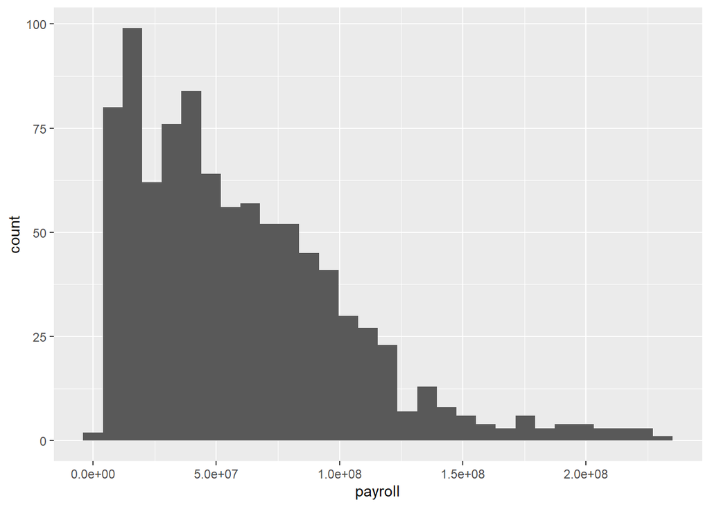

```r
# Distribution of payrolls
ggplot(data = teams_merged, aes(x = payroll)) +
  geom_histogram()
```

```r
# What could be causing this?
```

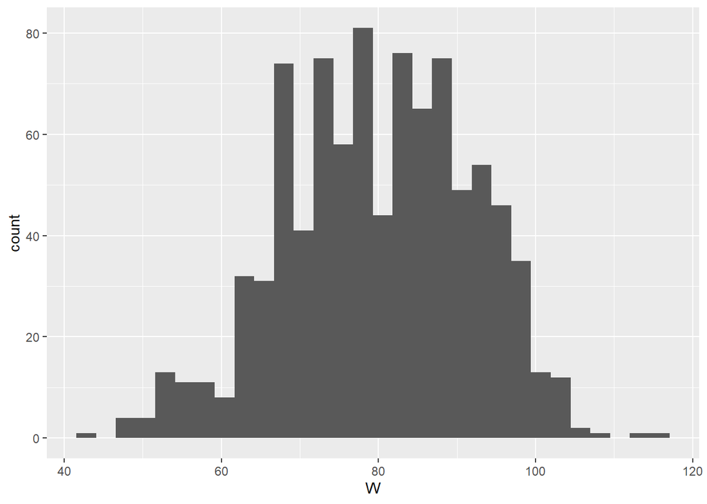

```r
# Distribution of wins
ggplot(data = teams_merged, aes(x = W)) +
  geom_histogram()
```

# 3rd base: Analyze the data

Depending how statistically informed you want to get, R can “probably” handle it! Let’s see what our payroll report might have in store…

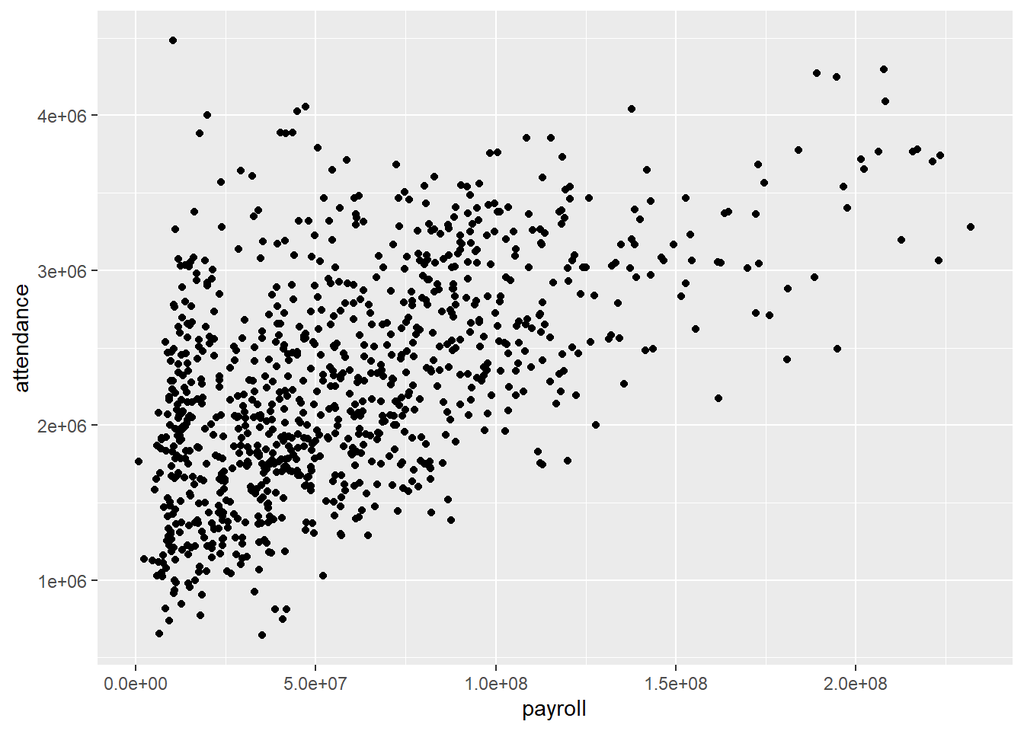

```r
# Relationship between payroll and attendance
ggplot(data = teams_merged, aes(x = payroll, y = attendance)) +
  geom_point()
```

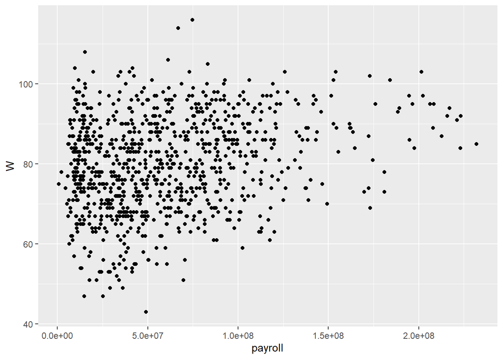

```r
# Relationship between payroll and wins
ggplot(data = teams_merged, aes(x = payroll, y = W)) +
  geom_point()
```

```r
# What if we take the log of payrolls?
teams_merged$log_payroll <- log(teams_merged$payroll)
head(teams_merged)
```

|  | yearID | teamID | name | attendance | W | payroll | log_payroll |
| --- | --- | --- | --- | --- | --- | --- | --- |
| 1 | 1985 | ATL | Atlanta Braves | 1350137 | 66 | 14807000 | 16.51061 |
| 2 | 1985 | BAL | Baltimore Orioles | 2132387 | 83 | 11560712 | 16.26312 |
| 3 | 1985 | BOS | Boston Red Sox | 1786633 | 81 | 10897560 | 16.20405 |
| 4 | 1985 | CAL | California Angels | 2567427 | 90 | 14427894 | 16.48467 |
| 5 | 1985 | CHA | Chicago White Sox | 1669888 | 85 | 9846178 | 16.10259 |
| 6 | 1985 | CHN | Chicago Cubs | 2161534 | 77 | 12702917 | 16.35734 |

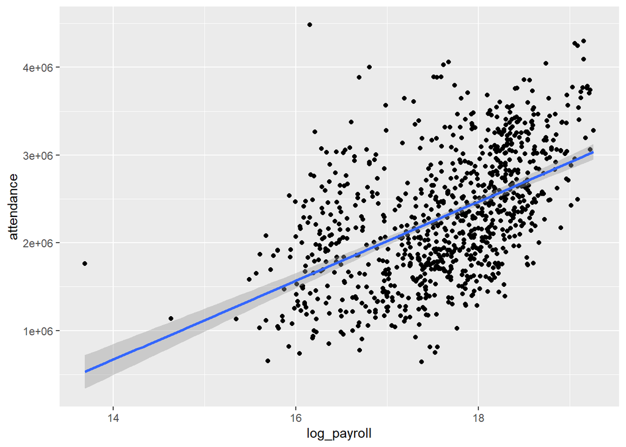

```r
# Relationship between payroll and attendance
ggplot(data = teams_merged, aes(x = log_payroll, y = attendance)) +
  geom_point() +
  geom_smooth(method = 'lm')
```

# Home: Export to Excel

There’s definitely more that could be done with our payroll/attendnance analysis, but let’s take our victory lap now :)

## Option A: `writexl`

If you want a pure data dump to Excel, `writexl` is a good option:

```r
# What do you want to write, and to where?
write_xlsx(teams_merged, 'output/writexl.xlsx')
```

```r
# What can this function do and not?
# Awesome Easter Egg
?write_xlsx
```

```
## starting httpd help server ... done
```

If you would like to fully automate the production from R, `openxlsx` is a good option:

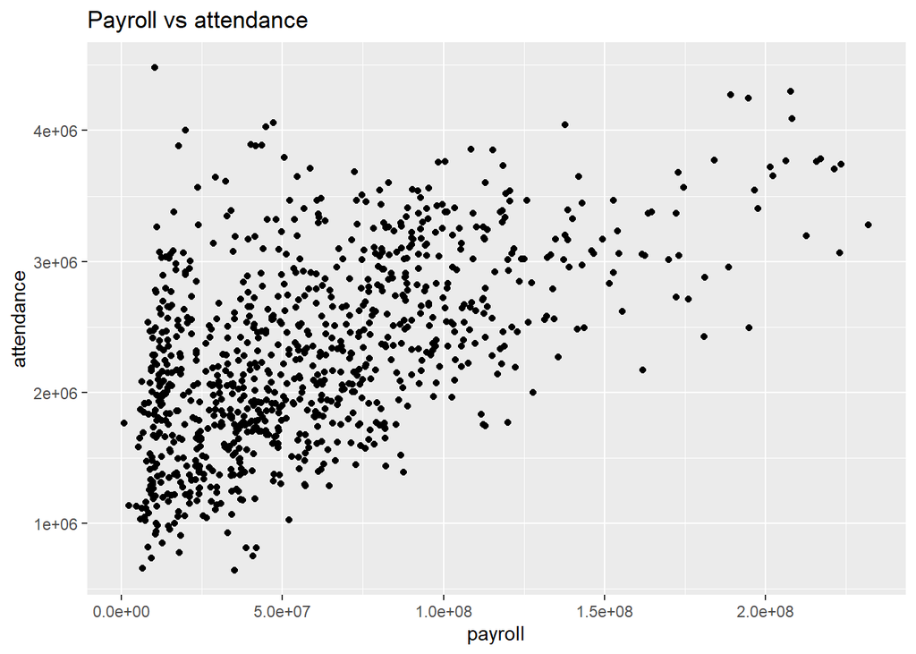

```r
# Add workbook
wb <- createWorkbook()

# Add worksheet of raw data
data_sheet <- addWorksheet(wb, sheetName = 'data')

# Write the dataset as a Table to Excel
writeDataTable(wb, sheet = data_sheet, x = teams_merged, rowNames = FALSE)


# Send plot to the workbook
ggplot(data = teams_merged, aes(x = payroll, y = attendance)) +
  geom_point() +
  ggtitle('Payroll vs attendance')
```

```r
# Add the image to the worksheet, set the placement
insertPlot(wb, sheet = data_sheet, startRow = 1, startCol = "I", width = 6, height = 4)

file = 'output/openxlsx.xlsx'

# save workbook to working directory
saveWorkbook(wb = wb, file = file, overwrite = TRUE)
```

We could even add cell formats, conditional formatting and so forth to Excel from R using this package. **Home run!**

Back to the slides for a conclusion…